# Upstate NYDBER 2026: Conference Report & Consensus-Building Summary

Cornell University · June 11–12, 2026

August 07, 2026

# Welcome

**Upstate NYDBER 2026** brought together Discipline-Based Education Research (DBER) scholars — across Physics (PER), Biology (BER), Engineering (EER), Chemistry (CER), Geoscience (GER), and related fields — from across Upstate New York for two days at Cornell University (June 11–12, 2026). The animating question: *what could this region’s DBER community build together that no single institution or field could build alone?*

The conference was designed as a **three-phase consensus-building process**:

| Phase | When | Focus |
| --- | --- | --- |
| **Before** | Pre-conference survey (53 responses) | Hopes for the conference; top barriers & enablers to InterDBER collaboration |
| **During** | Working group documents (9 small groups, both days) | Naming specific barriers, bright spots, design principles, and draft InterDBER research questions |
| **After** | Post-conference survey (21 responses) | Conference evaluation, concrete follow-up plans, and commitments |

*All individual quotes and comments below are anonymized and presented as themes, not attributed to named participants.*

# 1. Who Was in the Room

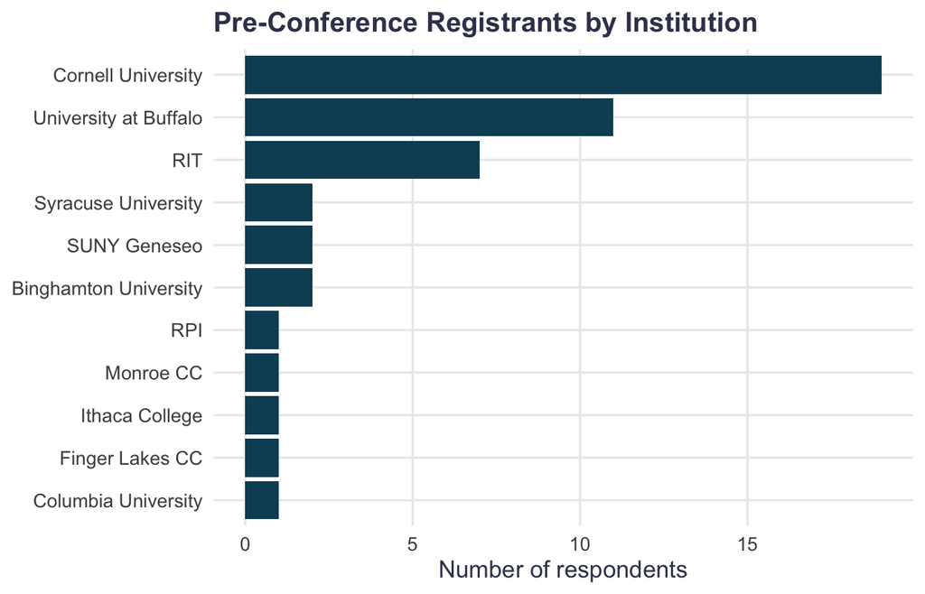

Nine small groups met throughout the conference (rotating between Working Group 1, Working Group 2, and the closing visioning session), each with 4–6 participants spanning multiple institutions, DBER fields, and career stages — from graduate students to senior faculty, across R1 universities, primarily-undergraduate institutions, and community colleges.

# 2. What People Came Hoping For

Pre-conference, participants described what they most hoped to get out of the conference and what they were bringing to share. Common threads:

- **Finding collaborators with complementary skills or shared interests** — a recurring “who should I be looking for” theme, often phrased as wanting someone from a specific institution type (community college, R1) or with specific methodological expertise.
- **Learning how other DBER fields approach shared problems** — assessment, AI in the classroom, and retention/belonging came up across many responses.
- **Bringing something concrete to the table** — datasets, methods expertise, or lived experience navigating a specific institutional barrier.

| What they hoped for |
| --- |
| someone who works at the intersection of math and engineering education, someone from a math program who would be interested in doing collaborative work with engineering, someone who can serve as a co… |
| anyone interested in programs to improve retention and student success |
| Anyone excited about mathematical reasoning! |
| I am excited to connect with other DBER scholars in NY in general, share my work and get feedback from my poster, and get my name out there. I would love to meet DBER scholars who are interested in ed… |
| I would be interested in connecting with other faculty who do work in biology / biomedical sciences career development, at the undergraduate or graduate level. I would also be interested in interactin… |
| People who have done research into ethics and identity formation; fellow EER students |

# 3. Poster Session Gallery

Two poster sessions ran across four tracks: **AI & Technology**, **Pedagogy & Assessment**, **Equity, Identity & Belonging**, and **Careers, Research Experiences & Curriculum/Community**. Presenters gave 30-second lightning talks before each session opened, and attendees were asked to visit at least one poster from their own DBER field and one from another.

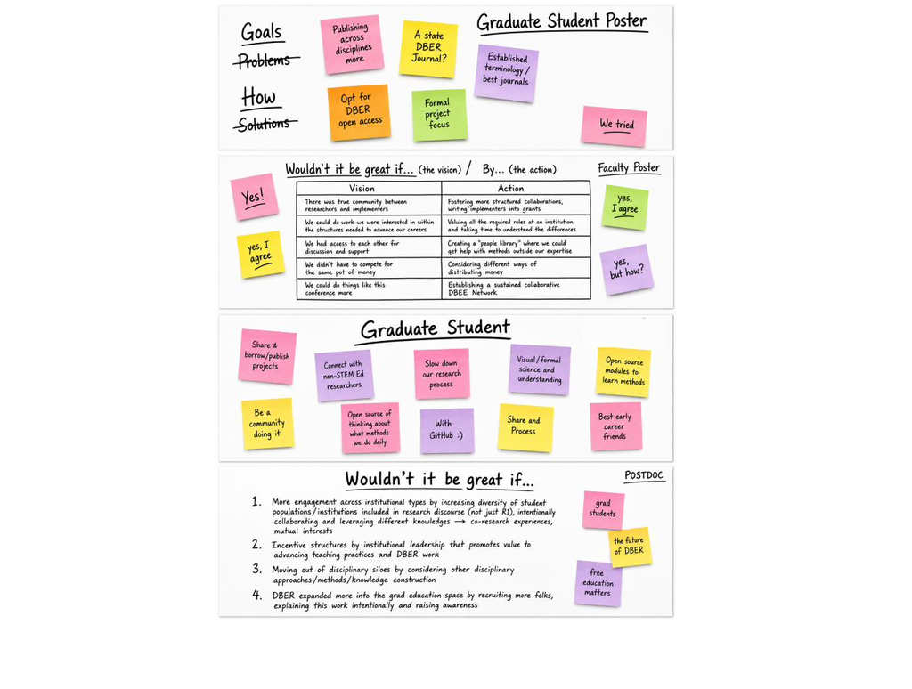

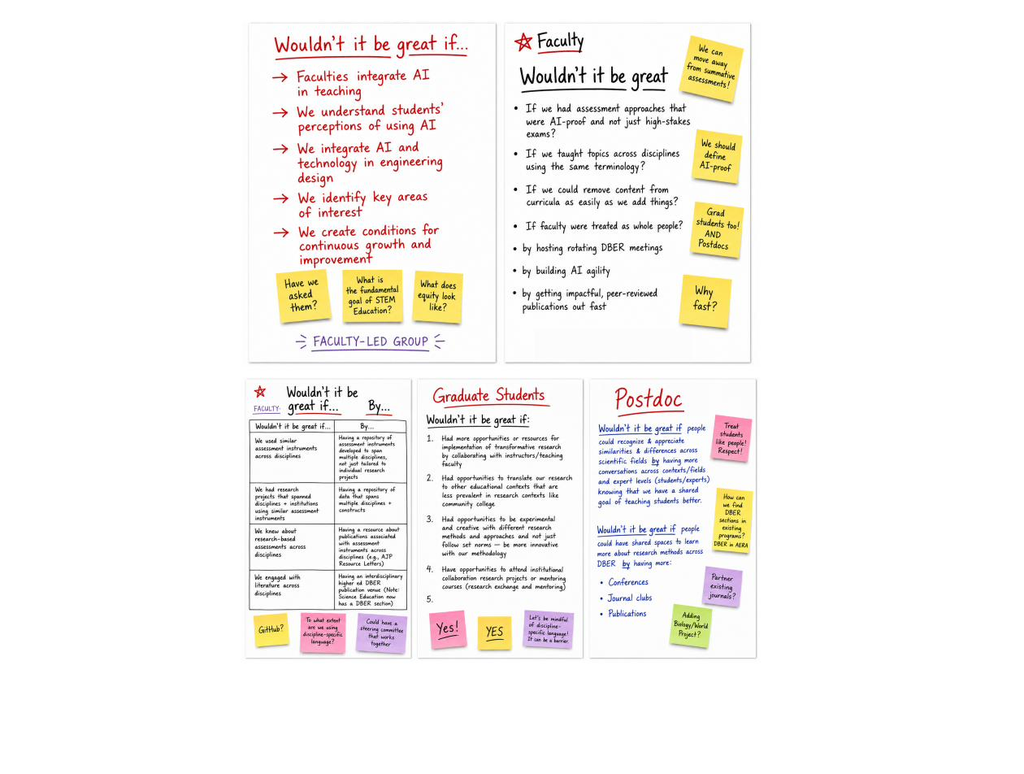

*(Poster images are AI-generated conference visuals summarizing the poster session; see the conference program for the full list of presenters and titles.)*

# 4. What Enables Collaboration

## 4.1 Pre-conference: ranked enablers

Before the conference, participants ranked what makes cross-institutional and InterDBER collaboration work well, from most to least important.

Cross-institutional collaboration enablers (pre-survey, ranked)

| Rank | Sample responses |
| --- | --- |
| 1st (most important) | Institutions being in similar time zones · Delegation of tasks without micromanaging · Finding stakeholders/collaborators who are interested in the same research |
| 2nd | Regular check-ins and meetings even when there is nothing to discuss (building habits o… · Opportunities to network, usually in person · Formal recognition of collaborators at other institutions throu… |
| 3rd | Establishing a relationship beyond the professional (friendships, non-work related casu… · Sharing specialized skills or knowledge · Institutional support (in tenure and promotion) for collaborative e… |

## 4.2 Working groups: bright spots

During Working Group 2, all nine groups discussed real collaborations that worked and what made them possible. Kept close to each group’s own language:

| Group | Enabler / bright spot |
| --- | --- |
| 1 | Open communication and lots of feedback between collaborators |
| 1 | Collaborations built on people who already know each other (e.g., met at a conference) |
| 1 | Mutual benefit / fair workload distribution |
| 1 | A person or people delegated to convene and organize the group |
| 1 | Clear, fair, transparent ownership across the team |
| 1 | Capitalizing on existing momentum |
| 2 | Broad planning and integration so everyone sees the big picture |
| 2 | Dedicated logistics/operations management for the collaboration |
| 3 | A welcoming, low-competition culture with strong internal collaboration (e.g., RIT CASTLE) |
| 3 | Shared desire to see the collective group succeed; shared office space |

[output cut: 24 more lines]

**Cross-cutting themes** that came up in multiple groups: clear/explicit communication and norm-setting; a designated convener or logistics lead; shared vision and mutual benefit; capitalizing on existing structures (centers like RIT’s CASTLE, Cornell’s CDER) that already create low-stakes, frequent cross-disciplinary contact; and in-person relationship-building as a precondition for trust.

# 5. What Blocks Collaboration

## 5.1 Pre-conference: ranked barriers

Barriers to InterDBER-field collaboration (pre-survey, ranked)

| Rank | Sample responses |
| --- | --- |
| 1st (hardest) | Establishing networks/lack of awareness of other DBER research, especially if someone’s… · DBER labs or programs are often siloed (or even the only ones at their institution) · Lack of common research… |
| 2nd | Differences in research trends, as the topic of interest may vary across different DBER… · History of separation to overcome · Lack of institutional support for initiatives of cross-collaboration |
| 3rd (easiest) | Discipline-blind methods designs are difficult to conceive · Different educational priorities within each field · Lack of knowledge about people willing to collaborate |

Barriers to cross-institution-type collaboration (pre-survey, ranked)

| Rank | Sample responses |
| --- | --- |
| 1st (hardest) | Administrative barriers, such as funding or researchers across different institution ty… · Knowing who is doing what and where · Lack of common institutional goals |
| 2nd | Need differences, as different institution types may have entirely different needs or c… · Coordination of time and resources · Lack of adequate support structures at institutions |
| 3rd (easiest) | Lack of awareness of shared research interests/networking opportunities · Effectiveness of remote meetings · Lack of individuals interested in collaboration |

## 5.2 Working groups: named barriers

Each Working Group 2 table named specific barriers and sorted them as **local vs. systemic** and **movable vs. hard to change**. This table is presented close to verbatim group language and is intended as the **starting list for the post-conference severity × changeability rating round** described in the conference design (see box below).

| Group | Barrier | Local / Systemic | Movable / Hard to change |
| --- | --- | --- | --- |
| 1 | Communication (interpersonal, across institutions) | Local | Movable |
| 1 | Communication norms may differ across institutions | Both | Depends |
| 1 | Uneven incentives/resources across institutions and positions | Both | Some movable, most hard |
| 2 | Misalignment of theoretical/epistemological norms across fields | Both | Depends |
| 2 | Misalignment of methodological norms across fields | Both | Depends |
| 2 | Structure mismanagement and misallocation of project tasks | Both | Movable |
| 3 | Niche/siloed topics (e.g., quantum education) harder to find collaborators for | Systemic | Hard |
| 3 | Different time scales/timelines for faculty, postdocs, grad students | Both | Depends |
| 3 | Different fields talk about education/topics differently (jargon) | Both | Movable |
| 3 | Funding | Systemic | Hard |

[output cut: 23 more lines]

> **Note on Group 5:** this table reported that *“almost all our barriers are systemic”* without naming individual items in the structured table — a useful data point in itself about how that group perceived the landscape.

### Barrier landscape at a glance

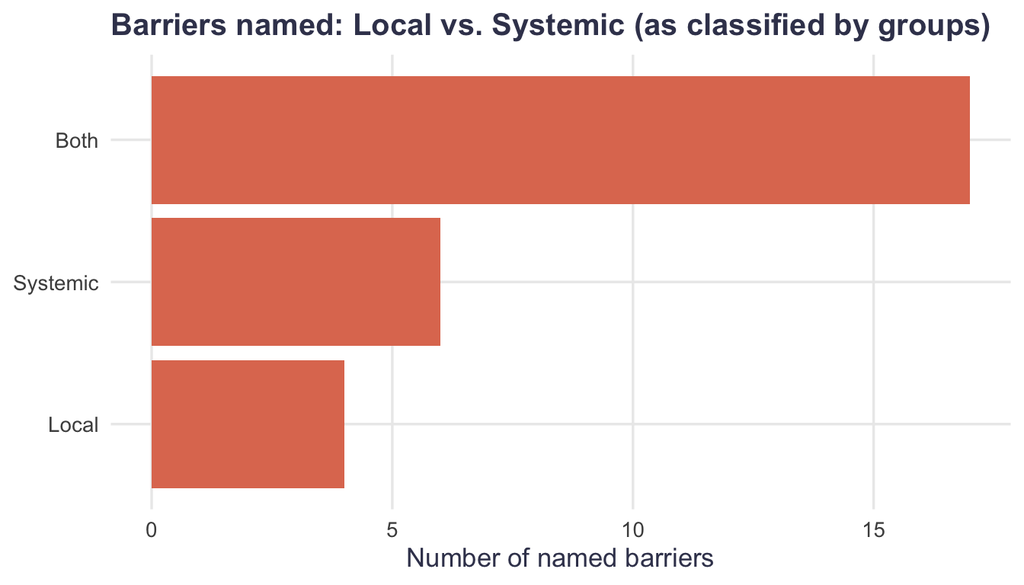

## 5.3 Next step: the severity × changeability rating

The conference design calls for a follow-up round in which all participants rate each consolidated barrier on **severity** (how much does it actually block collaboration?) and **changeability** (how realistically can this community address it?), and each enabler on **potential** and **feasibility**. That round has not yet been conducted. The table below is formatted as a ready-to-send rating instrument — the barrier/enabler language above, with empty columns for the next round of community input.

Sample of the barrier rating template (full version in data/wg2_barriers.csv)

| Item | Named by Group(s) | Severity | Changeability |
| --- | --- | --- | --- |
| Communication (interpersonal, across institutions) | 1 | NA | NA |
| Communication norms may differ across institutions | 1 | NA | NA |
| Uneven incentives/resources across institutions and positions | 1 | NA | NA |
| Misalignment of theoretical/epistemological norms across fields | 2 | NA | NA |
| Misalignment of methodological norms across fields | 2 | NA | NA |
| Structure mismanagement and misallocation of project tasks | 2 | NA | NA |
| Niche/siloed topics (e.g., quantum education) harder to find collaborators for | 3 | NA | NA |
| Different time scales/timelines for faculty, postdocs, grad students | 3 | NA | NA |
| Different fields talk about education/topics differently (jargon) | 3 | NA | NA |
| Funding | 3 | NA | NA |

# 6. Design Principles for Going Forward

Each Working Group 2 table proposed 1–4 design principles for InterDBER collaboration, paired with what each would look like in practice.

| Group | Principle | In practice |
| --- | --- | --- |
| 1 | Common vision for goals and process | Ground rules, a charter, frequent check-ins and revisions |
| 1 | No disciplinary hierarchies | Self-awareness of hierarchical/disciplinary bias; invite multiple disciplines to the table |
| 2 | Living documentation for onboarding | No single static source of truth; frequently reviewed decision log with rationale |
| 2 | Structure for projects | Assign roles/delegate early; everyone accounted for and held accountable |
| 2 | Reflexivity | Constant reflection on roles, delegation, and direction |
| 3 | Research into practice | Sharing interventions, especially with early-career/grad students |
| 3 | Sustaining involvement | At least one in-person touchpoint per year (e.g., one day in Rochester, more central) |
| 3 | Best matches | Matchmaking people working on similar ideas across fields |
| 3 | Inviting folks to give talks |  |
| 4 | Career inclusive (all ranks) | Space and time to revisit what deliverables support each person's career stage |

[output cut: 24 more lines]

Principles that surfaced independently across **multiple** tables: early-career and community-college inclusion, methodological pluralism, explicit/documented norms for credit and authorship, and building in space for “half-baked ideas” before they’re polished.

# 7. Draft InterDBER Research Questions

Working Group 1 asked each table to draft 1–3 research topics that genuinely require more than one DBER field to answer well.

| Group | Topic | Why InterDBER |
| --- | --- | --- |
| 1 | Universal conceptual frameworks across disciplines | Cross-field frameworks could unify how DBER fields describe learning |
| 1 | Attrition, retention, and sense of belonging | A shared concern across every DBER field |
| 1 | Technology adoption (AI, VR, and beyond) | New technologies cut across all STEM classrooms, not one discipline |
| 1 | Workforce competencies addressable across disciplines | Employers hire across disciplinary lines |
| 2 | Cross-field norms for AI use in teaching and research | Comp and bio, for example, need to reconcile norms once they collaborate |
| 2 | Institutional change / incentive structures across disciplines | Incentive structures (tenure, credit) span every DBER field |
| 3 | GenAI's impact on K-12 students before they reach STEM higher ed | Affects communication, critical thinking, and technical skills relevant to all DBER fields |
| 3 | Workforce preparation needs for STEM students | Many jobs/industries are interdisciplinary in nature |
| 4 | How instruction of foundational/service courses (e.g., stats) differs by discipline of instructor | Same content taught differently by a statistician vs. an engineer shapes student experience across fields |
| 4 | How different disciplines approach and teach 'failure' | Cross-cutting question about pedagogy and student experience |

[output cut: 12 more lines]

**Recurring topic clusters:** generative AI’s impact on students and pedagogy (named by more tables than any other topic); cross-field workforce/career pathways; how disciplines differ in teaching foundational/shared content; and assessment across disciplinary contexts.

# 8. Conference Feedback

Qualtrics stored these ratings as ordinal text labels (e.g., “Very Valuable”), not numbers, so we map each scale to 1–5 before plotting.

## 8.1 Overall experience

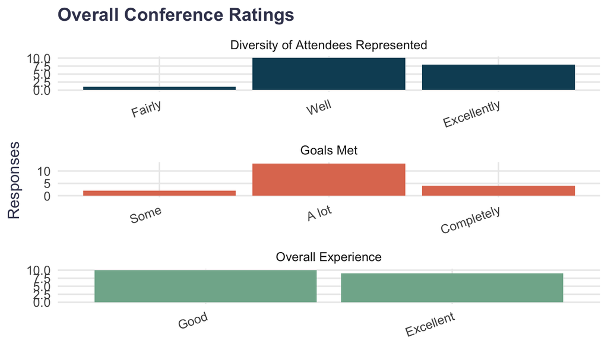

## 8.2 Component ratings

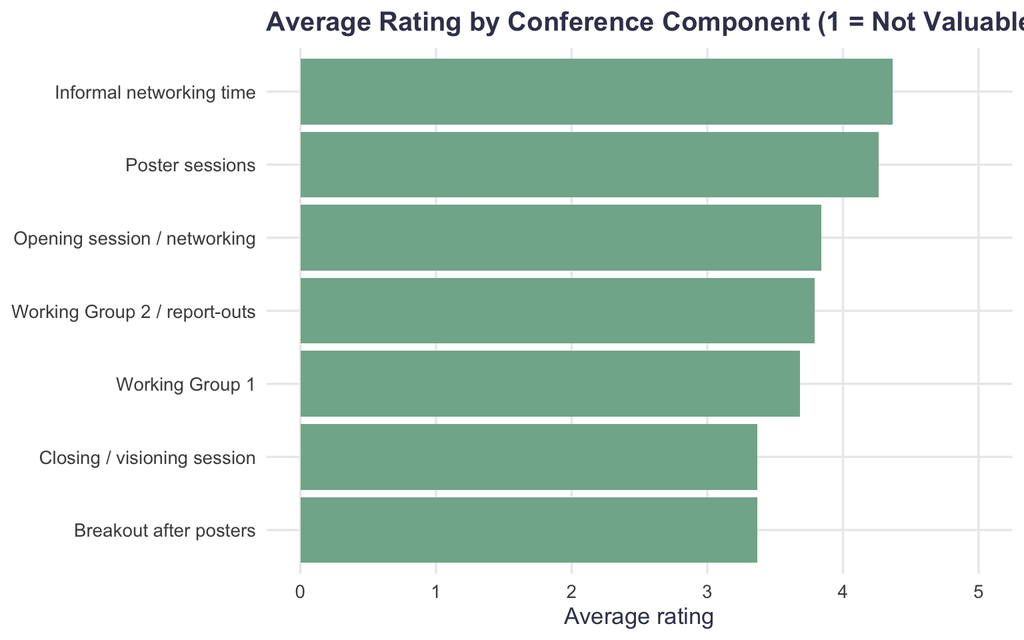

## 8.3 What people said was most valuable

| Most valuable aspect |
| --- |
| Becoming aware of upstate NY institutions with DBER groups and some of the ways in which these groups are internally organized/supported (CASTLE and CDER) and making some initial connections with peop… |
| Networking. It was good to connect with people who are working in DBER across fields and see where we have shared interests and concerns. |
| Getting feedback on work; Connecting with other DBER faculty at RIT |
| I liked the poster sessions the most, and I felt that gave me the best opportunity to learn about others’ research. |
| Collecting together people who may otherwise not be able to attend a research conference in one place, and connecting them with folks whose primary role is research. |
| meeting people from across the region and across fields |
| Informal chatting time |
| Making friends and sharing research in the poster session. |
| Meeting a lot of other regional folks. I like making in-person connections with people. |
| I enjoyed meeting and talking with researchers from other institutions and fields within DBER! |
| Connecting with researchers across the region, thinking about what the unique needs and strengths of our region are |
| Networking sessions. |
| Networking and connecting with the local community. |
| Loved getting to meet everyone of course, but also to get a view of the landscape of DBER in NY (I had no idea there were so many people in engineering education here in our state!) |
| As a grad student, I thought the informal connections I made with people in difference disciplines and at different career stages was made really easy. |
| Networking |
| Discussing commonalities and differences across our institutions, discussing systems level changes needed, and identifying concrete ways the interDBER community could support them. My favorite part wa… |
| Networking. |
| Learning about regional DBER programs and networking |

## 8.4 What could have improved the experience

| Suggested improvement |
| --- |
| The underlying goal seemed to be about trying to establish collaborations between DBER groups or between disciplines. But—for those of us outside of the already-established groups—I don’t think we’re … |
| I think having more time to talk about ongoing projects in a more structured way–birds of a feather discussions, or project ideation for collaborations would have been nice. |
| I would have been interested in some talks/panel sessions. The content grouping of the posters meant that people could not see each other’s work as well, but if there we 10 minute talks, we could each… |
| While I found the working groups valuable, I would have preferred more opportunities to hear more deeply about other DBER research (e.g., in poster sessions or, perhaps more preferably in talks). Perh… |
| I would have enjoyed a wider variety of activities—it felt like there was a lot of effort put on participants to make the conference valuable by continuing to have thoughtful conversation throughout t… |
| not staying with the same group as much for working sessions |
| More space and breaks for the introverts <3 |
| Maybe spacing the first day out a bit more. Also having some opportunities to go on walks/hikes with the visitors and doing informal active activities with them. |
| Attending both days…I had to miss Thursday because of a conflict. |
| I wished that some of the “breaks” were a bit longer, I had some of my best conversations during lunch and on a brief unplanned walk to the Dairy Bar |
| Nothing… I really thought it was very well done. |
| I felt like some of the workshops seemed to get repetitive towards the end, but that allowed for our group to network and learn about everyone’s work. I am grateful that I was able to join as a gradua… |
| A few more breaks or informal, unstructured time. |
| The first working groups session being based on the poster session was a little tough as a presenter, mostly in that I did not get the chance to fully get the landscape of what research was brought to… |
| The conference completely wiped my social battery by the end of the day on Thursday. I think all the discussion based work shops were phenomenal and are much more beneficial than filling a conference … |
| Honestly, it was a really great experience. I think it was a great balance of activities.. Would have liked more time for informal conversations. |
| 1 simple, concrete action item following the conference. It’s so easy to say “I have to follow up with XYZ!” and struggling to find the time afterwards. |
| Less structured time. |
| The conference was very well organized and managed. The prompts in the working documents helped me keep my group on task (and not get distracted with unproductive speeches) every time I was a notetake… |

## 8.5 Likely follow-through

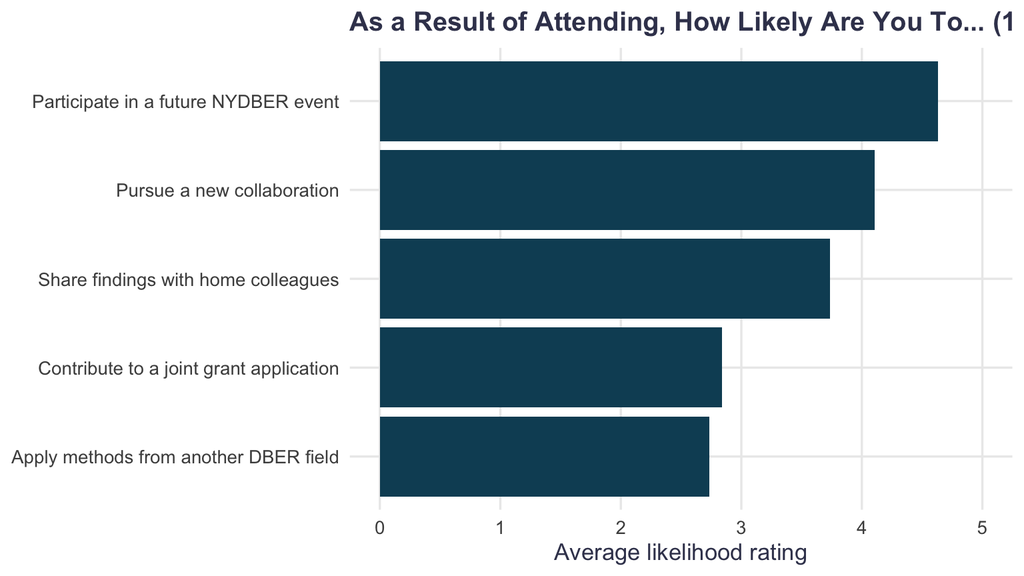

Concrete plans: several participants reported making specific follow-up plans with someone they met at the conference (see `Q33`/`Q34` in the raw data — kept private/aggregated here since these describe named collaborations).

# 9. Where This Goes Next

## 9.1 Sustainability mechanisms people said they’d actually use

Both the post-conference survey (Q24) and the closing-session visioning tables (1–5 enthusiasm ratings per mechanism) asked what would sustain this community. Combining both sources:

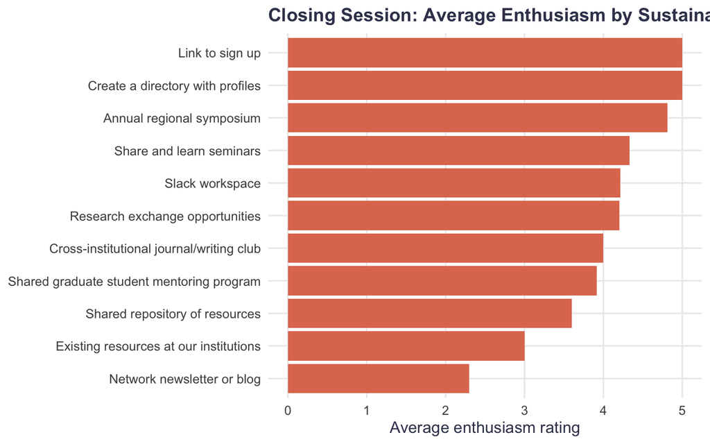

| Mechanism | Times selected (post-survey) |
| --- | --- |
| Annual regional symposium | 15 |
| Slack workspace for updates and communication | 13 |
| Virtual seminar series (e.g., works-in-progress presentations) | 12 |
| Shared graduate student training or mentoring program | 12 |
| Cross-institutional reading or writing group (monthly, virtual) | 9 |
| Shared repository of instruments, protocols, and resources | 8 |
| Listserv / email list | 7 |
| Job and opportunity sharing (postings, dissertation defenses, etc.) | 6 |
| Writing retreats (in-person or virtual) | 6 |
| Network newsletter or blog for sharing works-in-progress | 4 |
| Other: | 2 |

## 9.2 Three-month commitments

Participants committed to concrete next steps. Common patterns across the closing-session commitments and post-survey Q25 responses:

- Starting or joining a **journal club** at their home institution
- **Connecting** other DBER researchers at their institution to the network
- Following up directly with **specific people met at the conference**
- Advocating for the network with their institution’s leadership

# Appendix: Data Notes

- Pre-conference survey: 53 total responses (41 completed).
- Post-conference survey: 21 total responses (19 completed).
- Working group data drawn from 9 filled tables each for Working Group 1 (InterDBER research topics) and Working Group 2 (barriers, enablers, design principles), plus 9 closing-session visioning tables (sustainability ratings and commitments). A small number of tables did not fill in every field; those are reflected as gaps rather than inferred.
- All quotes and group notes are anonymized to theme-level or group-level attribution per project guidance; no individual names appear in this report.
- Structured source data for every table in this report lives in `data/` alongside this `.Rmd` file, so figures and tables can be re-run or extended directly.